# HW7_B66043

Dzvezdana Arsovska

April, 05 2017

## Exercise 1

Three classifiers gave the following quality:

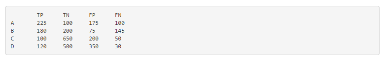

Calculate based on these tables the precision, recall, accuracy, F1-score (F-measure) for each classifier. Based on those, which are “best” classifiers?

**Solution:**

The classifiers can be represented using a confusion matrix which is a clear way to present the prediction results of a classifier.

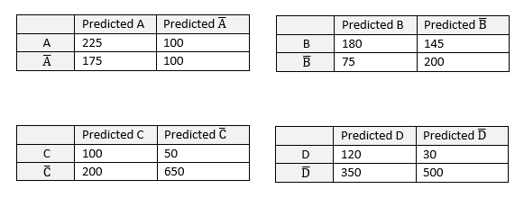

Based on the data in this tables we can calculate the precision, recall, accuracy and the F-measure for each classifier.

Precision or Positive Predictive Value is the number of positive predictions divided by the total number of positive class values predicted. Precision can be thought of as a measure of a classifiers exactness.

$$Precision = \frac{TP}{TP+FP}$$

Recall is the number of positive predictions divided by the number of positive class values in the test data. It is also called Sensitivity or the True Positive Rate. Recall can be thought of as a measure of a classifiers completeness. A low recall indicates many False Negatives.

$$Recall = \frac{TP}{TP+FN}$$

Accuracy is the proportion of correct results that a classifier achieved.

$$Accuracy = \frac{TP+TN}{TP+TN+FP+FN}$$

The F1 score (F-score) is a measure of a test’s accuracy. The F1 score can be interpreted as a weighted average of the precision and recall, where an F1 score reaches its best value at 1 and worst at 0.

$$F1 = \frac{2*precision*recall}{precision+recall}$$
The values for the precision, recall, accuracy and the F-measure are given in the following table.

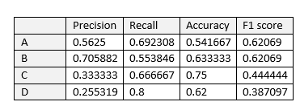

From the table we can conclude that B is the best classifier with the highest precision and high value for the F1 score. The classifier C has high accuracy value due to the in proportionally high number of TN in the confusion matrix.

## Exercise 2

Plot the information about these classifiers on the “ROC-space”.

1. Discuss the “goodness” of each classifier A, B, C, D using the scores from Task 1 and ROC space.
2. Discuss how does the imbalance of different labeled examples potentially impact the goodness measures?

**Solution:**

1. ROC curve, is a graphical plot that illustrates the performance of a binary classifier system. To draw a ROC curve, only the true positive rate (TPR) and false positive rate (FPR) are needed. The TPR defines how many correct positive results occur among all positive samples available during the test. FPR, on the other hand, defines how many incorrect positive results occur among all negative samples available during the test.

The best possible prediction method would yield a point in the upper left corner or coordinate (0,1) of the ROC space, representing 100% sensitivity (no false negatives) and 100% specificity (no false positives). The (0,1) point is also called a perfect classification. A random guess would give a point along a diagonal line (the so-called line of no-discrimination) from the left bottom to the top right corners.

A random guess would give a point along a diagonal line from the left bottom to the top right corners. Points above the diagonal represent good classification results (better than random), points below the line represent poor results (worse than random).

TPR and FPR can be calculated using:

$$TPR = \frac{TP}{TP+FN}$$

$$FPR = \frac{FP}{FP+TN}$$

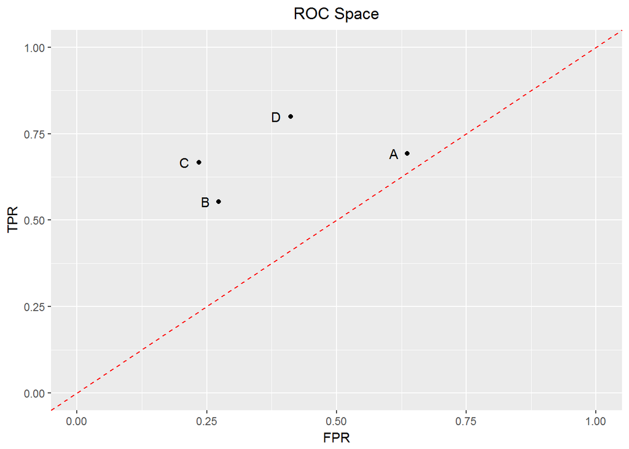

```r
# x calculated values for FPR, y calculated values for TPR for A,B,C,D
d <- data.frame(x = c(0.636363636, 0.272727273, 0.235294118, 0.411764706), y = c(0.692307692,
    0.553846154, 0.666666667, 0.8), names = c("A", "B", "C", "D"))

ggplot(d, aes(x, y)) + geom_point() + geom_text(aes(label = names, hjust = 2)) +
    xlab("FPR") + ylab("TPR") + ggtitle("ROC Space") + theme(plot.title = element_text(hjust = 0.5)) +
    geom_abline(intercept = 0, slope = 1, linetype = 2, colour = "Red") + xlim(0,
    1) + ylim(0, 1)
```

From the plot we can see that C is closest to the point (0,1). However from the metrics table in task 1 we can see that this classifier has very low precision and low F1 score. B is located closely to C and from task 1 we know that this is the best classifier. A had high values for the precision and the F1 score (compared to the other classifiers) but according to it’s location in the ROC space this classifier is close to being as good as random. D has the lowest precision and F1 score meaning that it is the worst classifier.

2. Accuracy measures the ratio of correct predictions to the total number of cases evaluated. Although it seems obvious that the ratio of correct predictions to cases should be a key metric that is not the case. A predictive model may have high accuracy, but be useless. This happens when we have a big difference in the number of (true or false) predicted negative and predicted positive cases. Then the accuracy can be misleading. Therefore it may be better to avoid the accuracy metric in favor of other metrics such as precision and recall.

## Exercise 3

Use the information about different classifiers from this file here. Each classifier outputs a score in which the “prediction” is made. Smaller score means higher “probability” by the method for the prediction, i.e. smaller ranking. Identify the order by which each classifier would classify data. Plot all three classifiers as ROC curves. Calculate AUC value for them and compare the classifiers.

**Solution:**

In order to plot a ROC curve we need to follow the following steps:

1. Sort the data according to the score;
2. Write down the true class according to the sorting;
3. Go ‘up’ for 1 and ‘right’ for 0;

```r
# Load the data
X <- fread("C:/Users/Arsovska/Desktop/HW7/ROC.csv")
X$ROC1order <- gsub(",", ".", X$ROC1order)
X$ROC2order <- gsub(",", ".", X$ROC2order)
X$ROC3order <- gsub(",", ".", X$ROC3order)
```

```r
# Sort the score
newdata1 <- X[order(ROC1order), ]

ROC1_sort <- newdata1$ROC1order
ROC1_sort <- as.numeric(ROC1_sort)
cls_sort1 <- newdata1$cls

newdata2 <- X[order(-ROC2order), ]

ROC2_sort <- newdata2$ROC2order
ROC2_sort <- as.numeric(ROC2_sort)
cls_sort2 <- newdata2$cls

newdata3 <- X[order(ROC3order), ]

ROC3_sort <- newdata3$ROC3order
ROC3_sort <- as.numeric(ROC3_sort)
cls_sort3 <- newdata3$cls
```

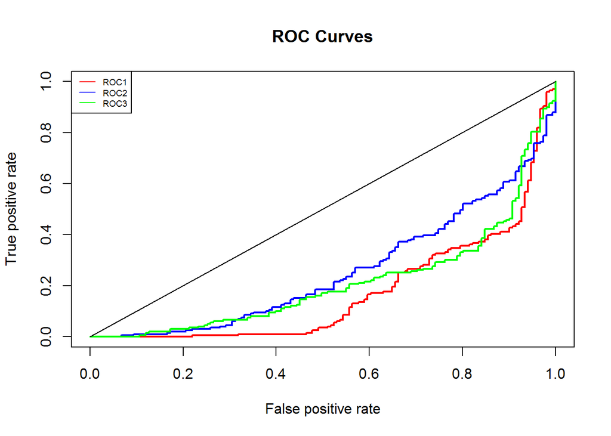

```r
# Plot the ROC curve using the sorted score and the true column using the
# ROCR library
pred1 = prediction(ROC1_sort, cls_sort1)
roc1 = performance(pred1, "tpr", "fpr")

pred2 = prediction(ROC2_sort, cls_sort2)
roc2 = performance(pred2, "tpr", "fpr")


pred3 = prediction(ROC3_sort, cls_sort3)
roc3 = performance(pred3, "tpr", "fpr")


plot(roc1, lwd = 2, col = "red", main = "ROC Curves")
plot(roc2, lwd = 2, col = "blue", add = TRUE)
plot(roc3, lwd = 2, col = "green", add = TRUE)
lines(x = c(0, 1), y = c(0, 1), col = "black", lwd = 1)

legend("topleft", legend = c("ROC1", "ROC2", "ROC3"), col = c("red", "blue",
    "green"), lty = 1, cex = 0.6)
```

```r
# Calculate the area under the curve
auc1 = performance(pred1, "auc")
auc1 = unlist(auc1@y.values)
auc1
```

```
## [1] 0.1720856
```

```r
auc2 = performance(pred2, "auc")
auc2 = unlist(auc2@y.values)
auc2
```

```
## [1] 0.256115
```

```r
auc3 = performance(pred3, "auc")
auc3 = unlist(auc3@y.values)
auc3
```

```
## [1] 0.2142833
```

From the plots and the auc scores it is obvious that the models performance is really bad. The reason for that is that for some reason the scores are assigned in a way that we give higher score for the FALSE guesses instead of the TRUE guesses. The optimal ROC curve would have only 1’s first when we sort the data and then only 0’s in which case we would have 100% sensitivity (no false negatives) and 100% specificity (no false positives). We can make this the classifiers better by inverting its prediction (i.e. invert the order of returning 0 and 1, then the position of the points in the ROC space would be (1- fpr, 1- tpr)).

Based on the auc scores Classifier 2 has the largest area under the curve meaning it is the “best” classifier and Classifier 1 is the worst.

Note:  
Using this code we can access the FPR, TPR and alpha values produced by ROCR’s performance function that is used for calculating the ROC curve.

```r
cutoffs <- data.frame(cut = roc1@alpha.values[[1]], fpr = roc1@x.values[[1]],
    tpr = roc1@y.values[[1]])
cutoffs <- cutoffs[order(cutoffs$tpr, decreasing = TRUE), ]
sub <- subset(cutoffs, cut >= 0.9)
```

## Exercise 4

Use the same data as in 3. Consider the different price for Type I and Type II errors. First, use prices as 10 and 100, and then 100 and 10; similarly 40-60 and 60-40. Identify optimal “cutoff” for these three classifiers using these pricing schemes. Highlight them on ROC curves.

**Solution:**

Type I error is the incorrect rejection of a true null hypothesis (a “false positive”, true 0 predicted 1), while a type II error is incorrectly retaining a false null hypothesis (a “false negative”, true 1 predicted 0). In other words, a type I error is detecting an effect that is not present, while a type II error is the failure to detect an effect that is present.

First using seq I am creating range of thresholds (whose range is based on the range of ROCSCORE1) and I create new columns for each value of the threshold that contain the results of the classification.

```r
for (i in 1:nrow(X)) {
    for (j in seq(0.1, 0.9, by = 0.01)) {
        n <- ifelse(X[, 3] > j, TRUE, FALSE)
        X[, paste0("treshold1_", j)] <- n
    }
}
```

We can visualize this results if we plot the threshold and the errors.

```r
X <- as.matrix(X)
true_pos1 <- colSums(X[, 1] == "TRUE" & X[, -1] == "TRUE")
true_neg1 <- colSums(X[, 1] == "FALSE" & X[, -1] == "FALSE")
type1_1 <- colSums(X[, 1] == "FALSE" & X[, -1] == "TRUE")
type1_w10_1 <- type1_1 * 10
min(type1_w10_1)
```

```
## [1] 0
```

```r
type1_w100_1 <- type1_1 * 100
min(type1_w100_1)
```

```
## [1] 0
```

```r
type1_w40_1 <- type1_1 * 40
min(type1_w40_1)
```

```
## [1] 0
```

```r
type1_w60_1 <- type1_1 * 60
min(type1_w60_1)
```

```
## [1] 0
```

```r
type2_1 <- colSums(X[, 1] == "TRUE" & X[, -1] == "FALSE")
type2_w100_1 <- type2_1 * 100
min(type2_w100_1)
```

```
## [1] 9500
```

```r
type2_w10_1 <- type2_1 * 10
min(type2_w10_1)
```

```
## [1] 950
```

```r
type2_w40_1 <- type1_1 * 40
min(type2_w40_1)
```

```
## [1] 0
```

```r
type2_w60_1 <- type1_1 * 60
min(type2_w60_1)
```

```
## [1] 0
```

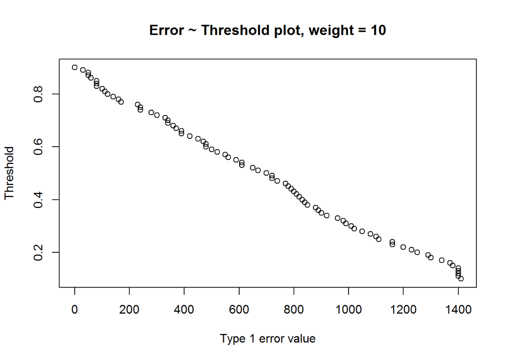

```r
ls1 = seq(0.1, 0.9, by = 0.01)
plot(ls1 ~ type1_w10_1, main = "Error ~ Threshold plot, weight = 10", xlab = "Type 1 error value",
    ylab = "Threshold")
```

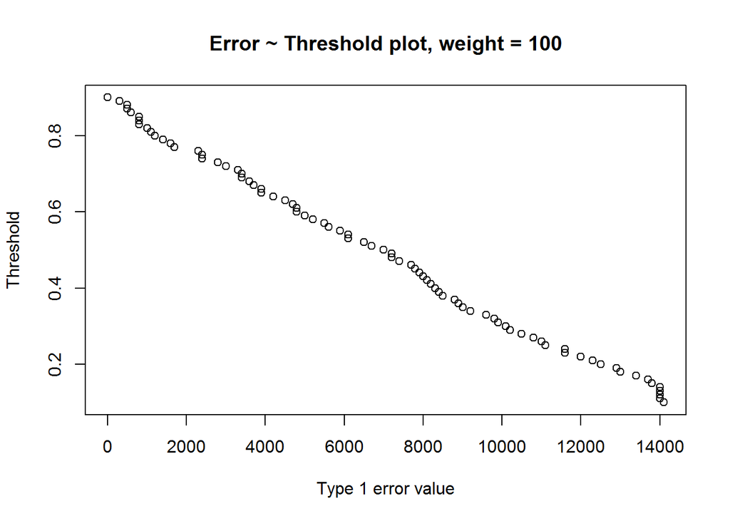

```r
plot(ls1 ~ type1_w100_1, main = "Error ~ Threshold plot, weight = 100", xlab = "Type 1 error value",
    ylab = "Threshold")
```

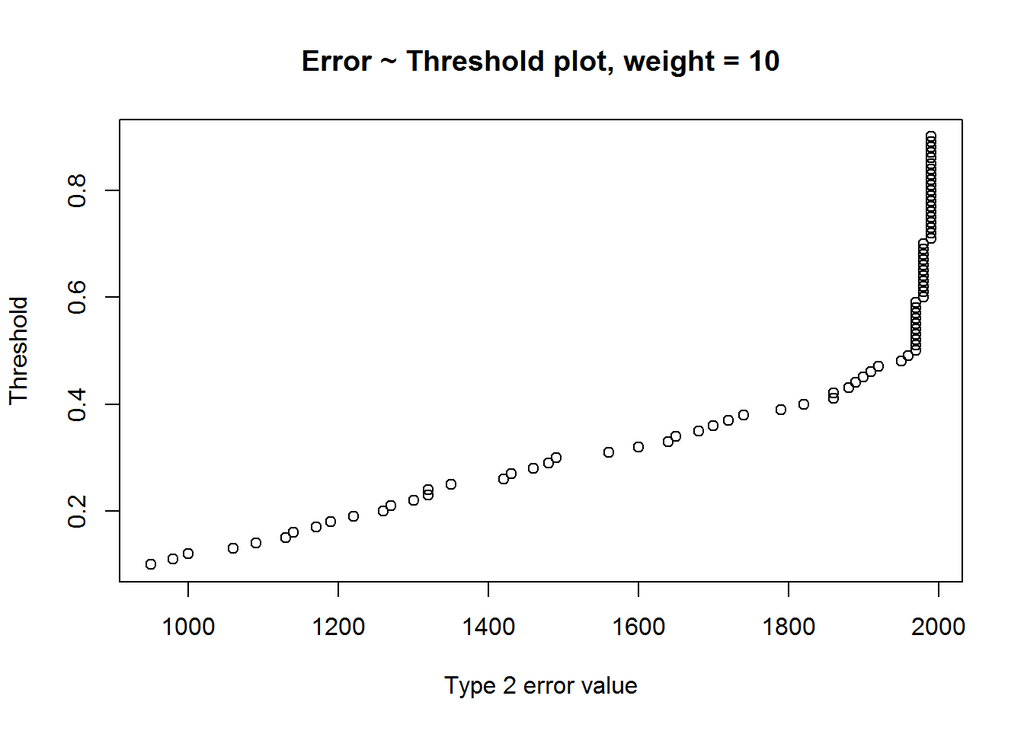

```r
plot(ls1 ~ type2_w10_1, main = "Error ~ Threshold plot, weight = 10", xlab = "Type 2 error value",
    ylab = "Threshold")
```

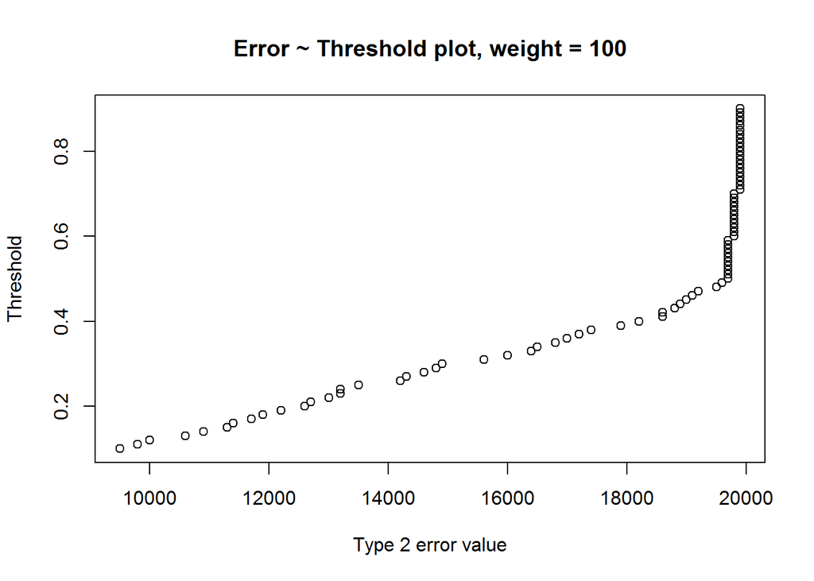

```r
plot(ls1 ~ type2_w100_1, main = "Error ~ Threshold plot, weight = 100", xlab = "Type 2 error value",
    ylab = "Threshold")
```

Similarly this can be done for the other two ROC scores.For the second ROC score the minimal value is 0 for all weights and this happens when the threshold is 520.

For the third ROC score the minimal value for the type1 error for all weights is 0 and this happens when the threshold is 0.1. The minimal value for the type2 error when the puce is:

- 10 is 1060, threshold is 0.1;
- 100 is 10600,threshold is 0.1;
- 40 is 4240 threshold is 0.1;
- 60 is 6360, threshold is 0.1;

The following plot shows the cut off frequencies based on the results:

[figure not shown]

## Exercise 5

Three different classifiers were presented individually in 3. Try to make an ensemble learner out of three. Try out two different methods of the four examples:

1. take the simple sum of three scores
2. scale the scores in order to weight more the “best” classifiers.
3. convert scores to ranks and take the sum of three ranks
4. use the sum of two best (or worst) ranks (out of three) as the new rank order.

Visualize on the same ROC curve plot with 3 individual plots. Which “ensemble” is your favorite?

**Solution:**

For this task I will use a) and b) to create the ensemble. First we need to calculate the sum and the weighted sum from the classifiers score. The classifiers who have higher auc values (calculated in task 3) are assigned with a higher number for the weights.

```r
for (i in 1:nrow(X)) {
    row <- X[i, ]
    sum = (X[, 3] + X[, 4] + X[, 5])
    X$sum = sum
}

for (i in 1:nrow(X)) {
    row <- X[i, ]
    weight_sum = (1.4 * X[, 3] + 2 * X[, +4] + 1.7 * X[, 5])
    X$weight_sum = weight_sum
}
```

Then we need to sort the scores.

```r
newdata1 <- X[order(sum), ]

sum_sort <- newdata1$sum
cls_sort1 <- newdata1$cls

newdata2 <- X[order(weight_sum), ]

wsum_sort <- newdata1$weight_sum
cls_sort2 <- newdata2$cls
```

Using the sorted scores we can plot the ROC curves and calculate the area under the curve.

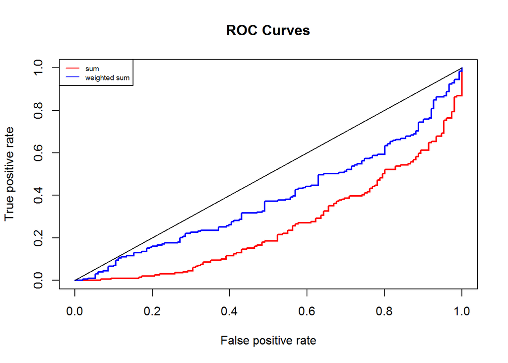

```r
pred1 = prediction(sum_sort, cls_sort1)
roc1 = performance(pred1, "tpr", "fpr")

pred2 = prediction(wsum_sort, cls_sort2)
roc2 = performance(pred2, "tpr", "fpr")

plot(roc1, lwd = 2, col = "red", main = "ROC Curves")
plot(roc2, lwd = 2, col = "blue", add = TRUE)
lines(x = c(0, 1), y = c(0, 1), col = "black", lwd = 1)

legend("topleft", legend = c("sum", "weighted sum"), col = c("red", "blue"),
    lty = 1, cex = 0.6)
```

```r
auc1 = performance(pred1, "auc")
auc1 = unlist(auc1@y.values)
# sum
auc1
```

```
## [1] 0.2543179
```

```r
auc2 = performance(pred2, "auc")
auc2 = unlist(auc2@y.values)
# weighted sum
auc2
```

```
## [1] 0.386968
```

Based on the auc values we can conclude that the weighted sum ensemble gives the best results, compared to the previous three models and the sum ensemble.

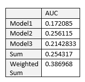

## Exercise 6

Can you build an ensemble using some clear rules based on the three classifier outputs that would beat all three individual ones, as well as the a-d from Task 5?

**Solution:**

To solve c and d from task 5 first we need to order all scores one by one and find the ranks. Then the ranks are sorted and their sum is found and used as the new score

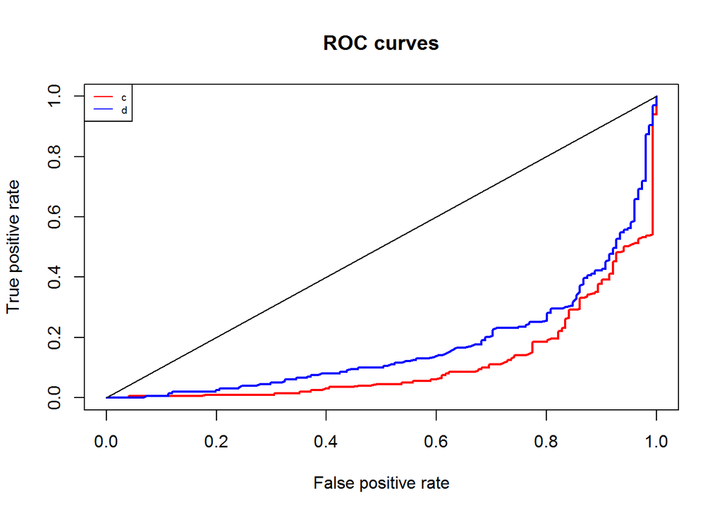

```r
X <- X[order(ROC1order), ]

for (i in 1:nrow(X)) {
    rank1 = 1:nrow(X)
    X$rank1 = rank1
}
X <- X[order(ROC2order), ]

for (i in 1:nrow(X)) {
    rank2 = 1:nrow(X)
    X$rank2 = rank2
}
X <- X[order(ROC3order), ]

for (i in 1:nrow(X)) {
    rank3 = 1:nrow(X)
    X$rank3 = rank3
}

# order all ranks
X <- X[order(X[, 6], X[, 7], X[, 8]), ]

# c sum of all 3 ranks
for (i in 1:nrow(X)) {
    sum = (X[, 6] + X[, 7] + X[, 8])
    X$sum = sum
}

# d sum of 2 ranks
for (i in 1:nrow(X)) {
    sum2 = (X[, 7] + X[, 8])
    X$sum2 = sum2
}

sum <- X$sum
sum2 <- X$sum2
cls <- X$cls

library(ROCR)

pred1 = prediction(sum, cls)
roc1 = performance(pred1, "tpr", "fpr")

pred2 = prediction(sum2, cls)
roc2 = performance(pred2, "tpr", "fpr")

plot(roc1, lwd = 2, col = "red", main = "ROC curves")
plot(roc2, lwd = 2, col = "blue", add = TRUE)
lines(x = c(0, 1), y = c(0, 1), col = "black", lwd = 1)

legend("topleft", legend = c("c", "d"), col = c("red", "blue"), lty = 1, cex = 0.6)
```

```r
auc1 = performance(pred1, "auc")

auc1 = unlist(auc1@y.values)
# Sum of 3 ranks
auc1
```

```
## [1] 0.1153949
```

```r
auc2 = performance(pred2, "auc")

auc2 = unlist(auc2@y.values)
# Sum of 2 ranks
auc2
```

```
## [1] 0.1714533
```

I decided to find the ratio between ROCSCORE2 and ROCSCORE3 for who we know from the previous task that they are better then the first classifier. Using this score, the area under the curve is 52% which is huge improvement from the previous guess and finally at least our guess is as good as random.

[figure not shown]

```r
for (i in 1:nrow(X)) {
    row <- X[i, ]
    div = (20 * X[, 4]/X[, 5])
    X$div = div
}

div <- X$div
cls <- X$cls

library(ROCR)

pred3 = prediction(div, cls)
roc3 = performance(pred1, "tpr", "fpr")


plot(roc3, lwd = 2, col = "red", main = "ROC curve")
lines(x = c(0, 1), y = c(0, 1), col = "black", lwd = 1)
```

```r
auc3 = performance(pred3, "auc")
auc3 = unlist(auc3@y.values)
auc3
```

```
## [1] 0.5157576
```